# Internship Report: Linking Structural Tree Traits to Sound Attenuation

Author

Published

February 1, 2026

# 1. Internship Position

The project investigated whether structural and morphological traits of trees can predict their acoustic filtering properties — specifically, how much sound attenuation occurs across different frequency bands when sound passes through a tree canopy. This sits at the intersection of forest ecology, acoustic physics, and urban planning, motivated by the role of urban trees as potential noise barriers.

# 2. Activities

## 2.1 Experimental Design and Planning (July–August 2025)

The project began with **terrestrial laser scanning (TLS)** of study trees at the Großpösna Arboretum near Leipzig (1 July 2025), conducted together with Max. These scans produced 3D point clouds of individual tree architecture, which would later serve as the structural data source.

## 2.2 Fieldwork (August–September 2025)

After rain delays and a test run on 28 August with Marc and Max (which revealed issues with distance correction and gain settings), the main measurements were conducted on 29 August and 2 September 2025. We measured **17 trees** across 10 species (5 broadleaf, 5 needleleaf), with one measurement per tree from one direction. The decision to measure one direction per tree and use a single reference was a pragmatic compromise given approaching leaf fall.

## 2.3 Acoustic Processing Pipeline (October–December 2025)

I developed a Python processing pipeline to extract transfer functions from the raw recordings: frequency-domain baselining, onset detection and trimming, deconvolution via regularized spectral division, Hann windowing (0.25 ms fade-in, 4.8 ms sustain, 1.0 ms fade-out), and transfer function extraction. Attenuation was computed as mean magnitude in dB within three generic frequency bands: low (125–500 Hz, traffic/machinery), mid (500–2,000 Hz, speech), and high (2,000–18,000 Hz, broadband), plus an overall band (125–18,000 Hz).

The codebase was refactored into modular components (`config.py`, `tree.py`, `processing.py`, `visualization.py`, `noise_profiles.py`, `slider.py`, `run_analysis.py`).

## 2.4 Structural Trait Extraction (November–December 2025)

I wrote R scripts to compute per-tree structural metrics from TLS point clouds: height, crown volume, volumetric fill fraction, directional gap fraction, leaf voxel density, ENL, FHD, and LAD. Leaf morphology traits (leaf area, thickness, LDMC, toughness) were extracted from the iDiv measurement database. The merged dataset comprised 12 predictors, 4 response variables, and 17 trees.

## 2.5 Statistical Analysis (January 2026)

Forward stepwise linear regression was performed separately for broadleaf (n=9), needleleaf (n=8), and mixed (n=17) groups, with a maximum of 3 predictors per model and four independent selection criteria (Adjusted R², BIC, LOOCV RMSE, F-test). The figure below shows how many of the four criteria selected each predictor, broken down by leaf type and frequency band.

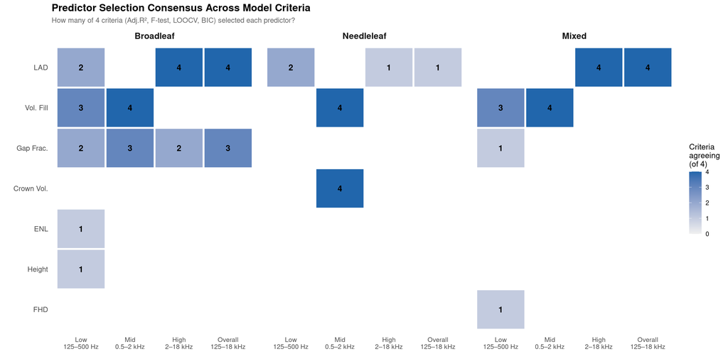

Predictor consensus across selection criteria. Each cell shows how many of 4 criteria selected that predictor for the given leaf type and band combination. Darker cells indicate stronger agreement.

## 2.6 Sonification with Urban Noise Scenarios (February 2026)

To make the acoustic results tangible, I recorded four urban noise scenarios — **highway traffic**, **tram/urban street**, **construction site**, and **children’s playground** — and filtered each through every tree’s windowed impulse response. This produces per-tree audio files (e.g., “highway through *Tilia tomentosa*”) that let listeners directly hear how different canopies attenuate different types of urban noise. The unfiltered recordings serve as A/B references. These audio examples are embedded in an interactive arboretum map where clicking a tree plays the filtered sound for the selected scenario.

# 3. Results

All 17 trees attenuated sound to varying degrees. Broadleaf trees tended toward stronger high-frequency attenuation; needleleaf patterns were more variable.

**Needleleaf:** Low and mid-frequency partially predictable. High-frequency and overall: conservative criteria selected null models with n = 8.

# 4. Evaluation

## Supervision

Excellent. Max provided ecological guidance, Marc contributed acoustic expertise, Christian Wirth offered strategic perspective, and Paul’s technical support was essential for fieldwork. The team was responsive and genuinely engaged with this unconventional research question.

## Work Assessment

The internship covered experimental design, fieldwork, TLS processing, Python and R programming, signal processing, statistical modeling, and interactive sonification. The breadth was both a strength and a challenge. The most valuable learning was the importance of checking results immediately during measurement campaigns — several issues surfaced only during later analysis.

## Limitations and Reflection

The main limitation is the small sample size (n ≈ 8–9 per group). Sixteen methodological limitations were systematically identified across measurement design (single direction, varying distances, no replication, no seasonal contrast), processing pipeline (arbitrary baselining range, fixed window, magnitude-only TF), and structural metrics (unjustified 3 m circle, LAD extinction coefficient from optics, ENL/FHD designed for stands). Each limitation was documented with a specific fix for future campaigns.

The acoustic processing pipeline was substantially refactored after the measurements; a repeat campaign with the current code would likely produce more robust results.

## Outlook

Three follow-up directions emerged: (1) the interactive slider as a sound installation tool, using recorded urban noise scenarios as the audio source for a more realistic listening experience; (2) seasonal leaf-on vs leaf-off measurements to isolate canopy contributions; and (3) scaling to MyDiv tree diversity plots with controlled species mixtures and larger sample sizes to address the question of whether biodiversity influences sound attenuation.